# Self-Efficacy and Performance of Research Skills Among First-Semester Bioscience Doctoral Students

This is an [R Markdown](http://rmarkdown.rstudio.com) Notebook detailing all of the data analysis completed for the paper entitled “Self-Efficacy and Performance of Research Skills Among First-Semester Bioscience Doctoral Students”.

**All analyses were performed by K. Lachance. This notebook was compiled on May 22, 2020.**

#Library Import

Import libraries and packages required for analysis and visualization and set seed for reproducibility.

```r
library(orddom) # Statistics
```

# Data Import

Import data, contained in ExperimentalDesignData.csv file. Each row corresponds to a student (identified with an anonymous code) and each column contains information about that student’s response about research skills self-efficacy, experimental design aptitude, experience, and demographic information. In total, 103 students were surveyed (only students that completed all pre- and post-test assessments were included in this study).

```r
# Print output
cat(paste("There are ", numStudents, " student responses contained in the following analyses.\n", sep =""))
```

```
There are 103 student responses contained in the following analyses.
```

# Figure 1

Length of time spent doing pre-doctoral research is not predictive of student research skills self-efficacy or self-reported experience and comfort with experimental design.

*Figure 1A*

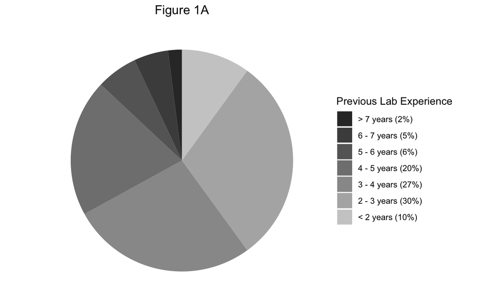

*Figure 1B*

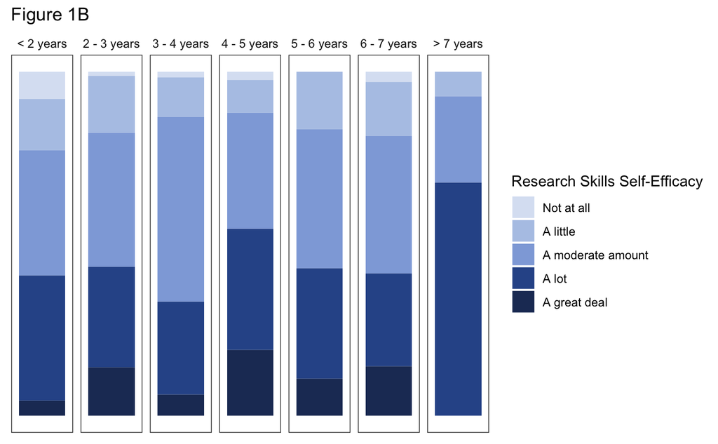

*Figure 1Ci*

```r
# Calculate linear regression
lm_exp = lm(formula = ExperimetalDeignExperience ~ LabExp, data = data)
summary(lm_exp) # Adjusted R-squared:  0.06328
Exp_Radj = round(0.06328, 2)

# Scatter plot
fig1ci <- ggplot(data, aes(x = LabExp, y = ExperimetalDeignExperience)) +
  geom_jitter(width = 0.25, height = 0.25, size = 2, color = "#808080") +
  annotate("text", x = 7, y = 5, label = paste("R2 = ", Exp_Radj, sep="")) +
  scale_x_continuous("Previous years working in lab", breaks=c(1:7), limits=c(0.5,7.5), labels = c("< 2 years", "2 - 3 years", "3 - 4 years", "4 - 5 years", "5 - 6 years", "6 - 7 years", "> 7 years")) +
  scale_y_continuous("Self-reported experience\nwith experimental design", breaks=c(1:5), limits=c(0.5,5.5), labels = c("None", "Minimal", "Some", "Moderate", "Extensive")) +
  theme_bw() +
  theme(panel.grid.minor = element_blank()) +
  ggtitle("Figure 1Ci") + theme(plot.title = element_text(hjust = 0.5))

plot(fig1ci)
ggsave(fig1ci, filename="./Figures/Fig1Ci.svg", width = 4, height = 3)
```

[output not shown]

*Figure 1Cii*

[figure not shown]

*Figure 1Di*

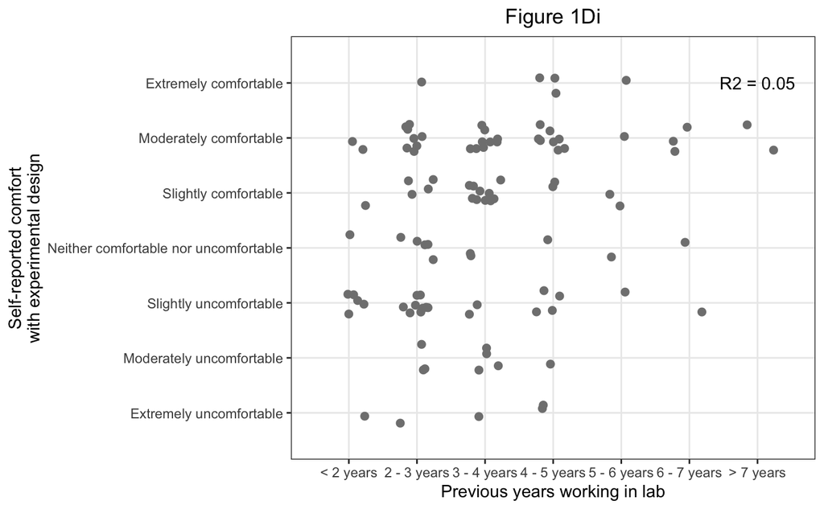

*Figure 1Dii*

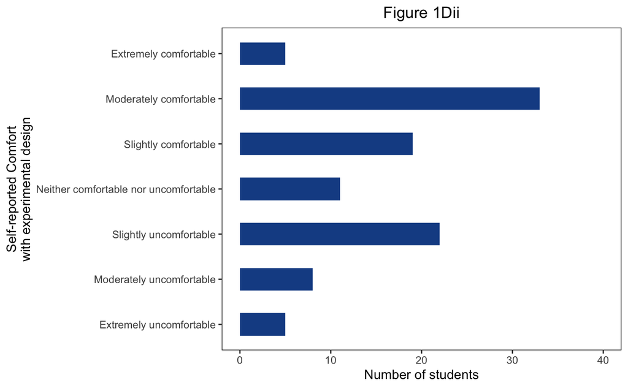

# Figure 2

Students improved their performance of experimental design over the first semester of doctoral training.